# Regressione lineare: aggiungere variabili esplicative

```r
# library(tidyverse)
library(dplyr)
library(readxl)
library(HH)
library(sjPlot)
```

# Regressione lineare semplice: testare gli assunti

Nell’analisi precedente, abbiamo analizzato la relazione che intercorre tra la longevità degli animali, e la densità nell’anno della nascita. Sappiamo però che la longevità dipende probabilmente da molti fattori che agiscono contemporaneamente, e che la densità nell’anno di nascita è probabilmente soltanto uno di questi. Ad esempio, avevamo già visto come la longevità fosse significativamente diversa tra femmine che si sono riprodotte e femmine che non si sono riprodotte.  
Per questo motivo, è più oppurtuno, spesso, considerare dei modelli di regressione più complessi di quello che abbiamo visto sino ad ora, ed inserire più variabili esplicative (*x*) per comprendendere cosa succede alla nostra variabile dipendente (*y*, in questo caso è la longevità).

Quindi rileggiamo e prepariamo di nuovo i dati - in questo caso non separiamo i dati degli individui che si sono riprodotti da quelli che non si sono riprodotti:

```r
mydata <- read_excel("data/CawRidge_LifetimeData.xlsx")
```

[output not shown]

Fittiamo ora il modello di base ai dati:

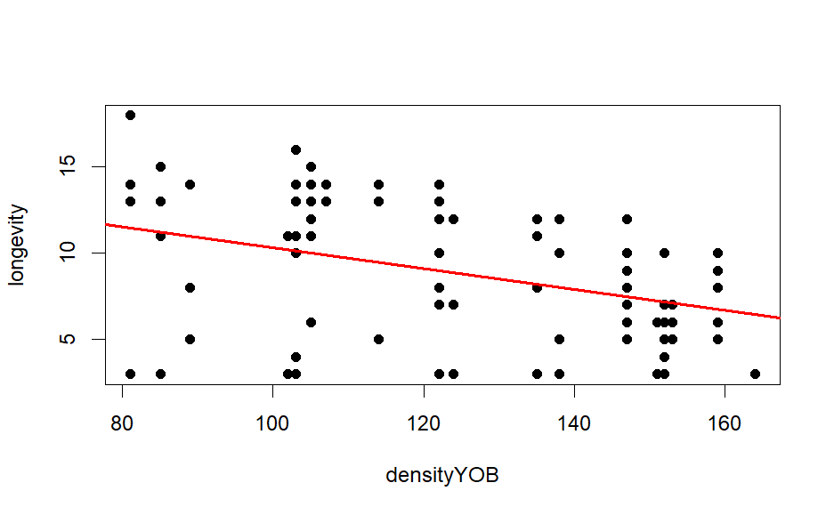

```r
mod_v1 <- lm(longevity ~ densityYOB, data = mydata)
plot(longevity ~ densityYOB, data = mydata, pch = 16)
abline(coef(mod_v1), col="red", lwd=2)
```

```r
summary(mod_v1)
```

```
Call:
lm(formula = longevity ~ densityYOB, data = mydata)

Residuals:
    Min      1Q  Median      3Q     Max
-8.4429 -2.3389  0.5113  3.0250  6.5571

Coefficients:
            Estimate Std. Error t value Pr(>|t|)
(Intercept) 16.29576    1.90879   8.537 1.47e-13 ***
densityYOB  -0.05991    0.01489  -4.023 0.000111 ***
---
Signif. codes:
0 ‘***’ 0.001 ‘**’ 0.01 ‘*’ 0.05 ‘.’ 0.1 ‘ ’ 1

Residual standard error: 3.682 on 101 degrees of freedom
Multiple R-squared:  0.1381,    Adjusted R-squared:  0.1296
F-statistic: 16.18 on 1 and 101 DF,  p-value: 0.0001112
```

Confrontate questo grafico con quello che avevemo ottenuto sulle sole femmine che si erano riprodotte, e inoltre notate, nell’output precedente, il valore di R2, che è decisamente basso.

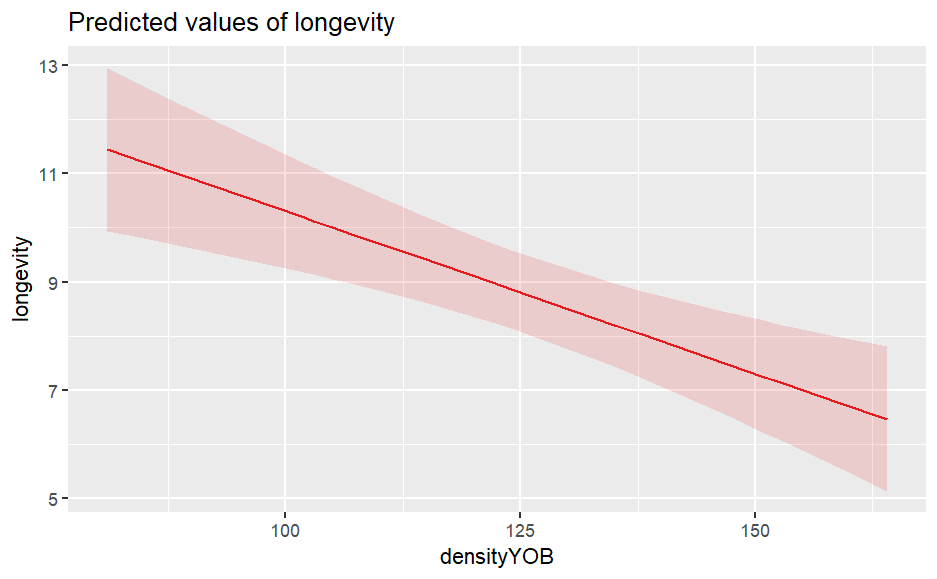

```r
plot_model(mod_v1, type = "eff", terms = "densityYOB")
```

Aggiungiamo ora una nuova variabile esplicativa, relativa alla riproduzione. In questo caso si tratta di una variabile binaria, o dicotomica, che può assumere soltanto valore 0 o 1. **NB. POSSIAMO AGGIUNGERE ALL’ANALISI DI REGRESSIONE VARIABILI ESPLICATIVE DI TIPO DIVERSO (CONTINUE, CATEGORICHE, DICOTOMICHE)**

```r
mod_v2 <- lm(longevity ~ densityYOB + repr, data = mydata)
summary(mod_v2)
```

```
Call:
lm(formula = longevity ~ densityYOB + repr, data = mydata)

Residuals:
    Min      1Q  Median      3Q     Max
-5.8396 -1.9141 -0.2472  2.1788  7.0984

Coefficients:
            Estimate Std. Error t value Pr(>|t|)
(Intercept) 10.75166    1.51494   7.097 1.87e-10 ***
densityYOB  -0.04937    0.01095  -4.509 1.78e-05 ***
repryes      5.71627    0.60656   9.424 1.81e-15 ***
---
Signif. codes:
0 ‘***’ 0.001 ‘**’ 0.01 ‘*’ 0.05 ‘.’ 0.1 ‘ ’ 1

Residual standard error: 2.693 on 100 degrees of freedom
Multiple R-squared:  0.5435,    Adjusted R-squared:  0.5344
F-statistic: 59.53 on 2 and 100 DF,  p-value: < 2.2e-16
```

In generale, il comando `plot` applicato al modello ci permette poi di ottenere tutti i plot diagnostici:

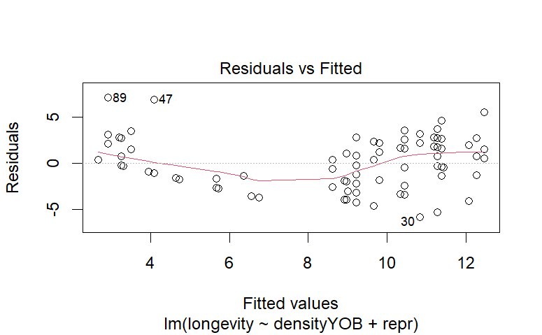

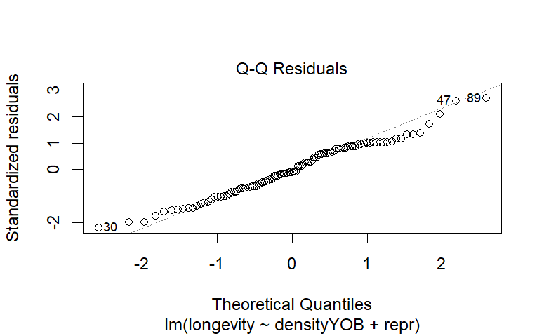

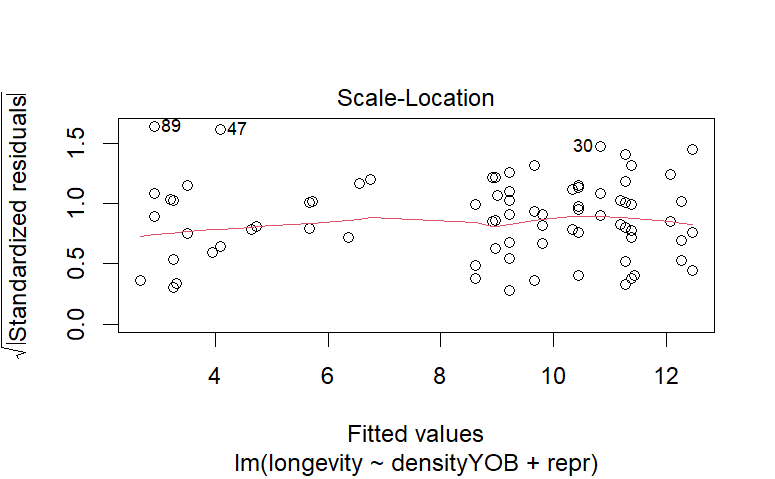

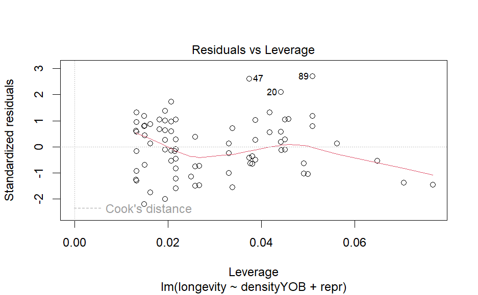

```r
plot(mod_v2)
```

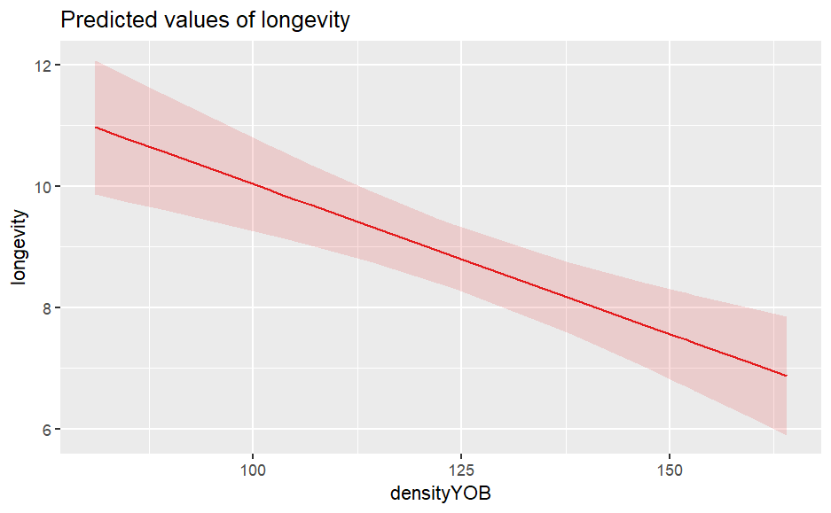

```r
plot_model(mod_v2, type = "eff", terms = "densityYOB")
```

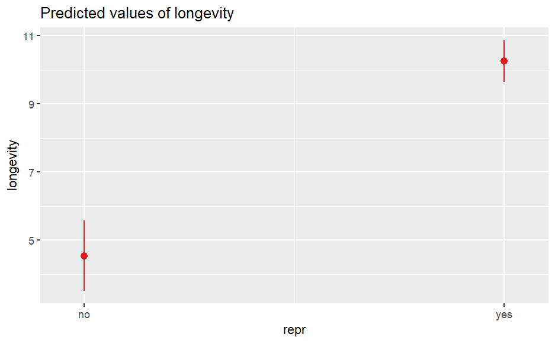

```r
plot_model(mod_v2, type = "eff", terms = "repr")
```

Come vediamo, in questo caso abbiamo sempre un’unica retta di regressione che descrive il decremento della longevità all’aumentare della densità nell’anno di nascita. Ma sappiamo che la longevità dipende anche dalla riproduzione.

E se la longevità cambiasse in modo diverso, in funzione della densità, a seconda della condizione riproduttiva?  
Possiamo testare questa ipotesi inserendo un termine di interazione:

```r
mod_v3 <- lm(longevity ~ densityYOB * repr, data = mydata)
summary(mod_v3)
```

```
Call:
lm(formula = longevity ~ densityYOB * repr, data = mydata)

Residuals:
    Min      1Q  Median      3Q     Max
-6.2065 -1.4063  0.0297  1.7177  6.5248

Coefficients:
                   Estimate Std. Error t value Pr(>|t|)
(Intercept)         0.64374    2.28862   0.281    0.779
densityYOB          0.02838    0.01725   1.645    0.103
repryes            20.23653    2.72243   7.433 3.85e-11 ***
densityYOB:repryes -0.11324    0.02082  -5.440 3.86e-07 ***
---
Signif. codes:
0 ‘***’ 0.001 ‘**’ 0.01 ‘*’ 0.05 ‘.’ 0.1 ‘ ’ 1

Residual standard error: 2.375 on 99 degrees of freedom
Multiple R-squared:  0.6486,    Adjusted R-squared:  0.6379
F-statistic:  60.9 on 3 and 99 DF,  p-value: < 2.2e-16
```

Guardate il valore di R2 e confrontatelo con quello dei modelli precedenti: questo modello è migliore!

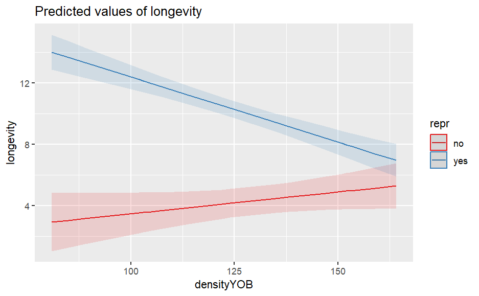

```r
plot_model(mod_v3, type = "int")
```